# Chapter1: What Is Data Science?

M. Affouf

January 14, 2018

## 1.1 Big Data and Data Science Hype

What is *big data* and what is *data science*?  
Is data science the science of Big Data?  
Is data science just an extension of statistics?

From wikipedia: [Data Science](https://en.wikipedia.org/wiki/Data_science) is the extraction of knowledge from large volumes of data that are structured or unstructured, which is a continuation of the field *data mining* and *predictive analytics*, also known as *knowledge discovery and data mining* (KDD). “Unstructured data” can include emails, videos, photos, social media, and other user-generated content. Data science often requires sorting through a great amount of information and writing algorithms to extract insights from this data.

## 1.2 Getting Past the Hype

Whenever you go from school to a real job, you realize there’s a gap between what you learned in school and what you do on the job.  
* Why do many courses in school have to be so out of touch with reality?  
* The general experience of data scientists is that, at their job, they have access to a larger body of knowledge and methodology, as well as a process, which we now define as the *data science process*, that has foundations in both statistics and computer science.

Data scientists must have a large body of knowledge, use many tools, and understand the *data science process*. The skills go well beyond the foundations learned in computer science, mathematics, and statistics.

## 1.3 Why Now?

We have massive amounts of data about many aspects of our lives, and, simultaneously, an abundance of inexpensive computing power. It’s not just Internet data! There is a growing influence of data in most sectors and in most industries.

Data science evolved with the *datafication* of our online and offline data. Data, often *real time*, becomes the building blocks of *data products*:  
* Amazon recommendations  
* Facebook friend recommendations  
* Credit ratings and trading algorithms in finance  
* Personalized learning and assessment in education

We’re witnessing the beginning of a massive, culturally saturated feedback loop where our behavior changes the product and the product changes our behavior.

### 1.3.1 Datification

Datafication: taking all aspects of life and turning them into data.  
* Google’s or [Meta’s](https://www.getameta.com) augmented-reality glasses datafy the gaze.  
* Twitter datafies stray thoughts.  
* LinkedIn datafies professional networks.

We and our actions are being datafied often without our knowledge.

Once we datafy things, we can transform their purpose and turn the information into new forms of value.  
* The “we” is the modelers and entrepreneurs making money from getting people to buy stuff.  
* The “value” translates into something like increased efficiency through automation.

## 1.4 The Current Landscape (with a Little History)

According to Drew Conway data science is at the intersection of math and statistics, hacking skills, and substantive expertise. (See Figure 1-1.)

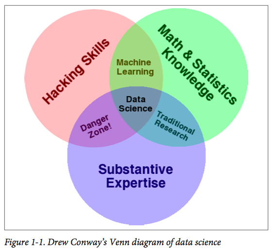

Data Science Venn Diagram

He further states:  
* Data science, as it’s practiced, is a blend of Red-Bull-fueled hacking and espresso-inspired statistics.  
* But data science is not merely hacking because when hackers finish debugging their Bash one-liners and Pig scripts, few of them care about non-Euclidean distance metrics.  
* And data science is not merely statistics, because when statisticians finish theorizing the perfect model, few could read a tab-delimited file into R if their job depended on it.  
* Data science is the civil engineering of data. Its acolytes possess a practical knowledge of tools and materials, coupled with a theoretical understanding of what’s possible.

Who coined the term data science?  
[Jef Wu: Statistics=Data Science?](https://en.wikipedia.org/wiki/C.F._Jeff_Wu), researchers at LinkedIn and Facebook, or [Bill Cleveland](http://www.stat.purdue.edu/~wsc/papers/datascience.pdf)—a statistician.

Also see Larry Wasserman’s [talk](http://www.stat.wvu.edu/~jharner/Interface2015Slides/WassermanKeynoteSlides.pdf) at Interface 2015.

### 1.4.1 Data Science Jobs

Data scientists need to know mathematics, statistics, and machine learning. But they also must have strong computer science, presentation, and data visualization skills, and domain expertise.

Both [Cornell](http://tech.cornell.edu/news/fast-company-introducing-the-bridge) and Columbia have large data science initiatives. This pattern is being repeated around the world.

## 1.5 A Data Science Profile

What are your skill levels in the following:  
* Computer science  
* Math  
* Statistics  
* Machine learning  
* Domain expertise  
* Communication and presentation skills  
* Data visualization

A data science team works best when different skills (profiles) are represented across different people, because nobody is good at everything.

It is my view that all data scientists must have knowledge of and be good at [functional programming](http://adv-r.had.co.nz/Functional-programming.html).

## 1.6 Thought Experiment: Meta-Definition

Can we use data science to define data science?  
* Using a text-mining model  
* Applying a clustering algorithm

Also, see [Analyzing the Analyzers](http://shop.oreilly.com/product/0636920029014.do) at O’Reilly.

## 1.7 OK, So What Is a Data Scientist, Really?

Perhaps the most concrete approach is to define data science is by its usage.

### 1.7.1 In Academia

``An academic data scientist is a scientist, trained in anything from social science to biology, who works with large amounts of data, and must grapple with computational problems posed by the structure, size, messiness, and the complexity and nature of the data, while simultaneously solving a real-world problem.’’

### 1.7.2 In Industry

``A data scientist is someone who knows how to extract meaning from and interpret data, which requires both tools and methods from statistics and machine learning, as well as being human. She spends a lot of time in the process of collecting, cleaning, and munging data, because data is never clean. This process requires persistence, statistics, and software engineering skills—skills that are also necessary for understanding biases in the data, and for debugging logging output from code.’’

``Once she gets the data into shape, a crucial part is exploratory data analysis, which combines visualization and data sense. She’ll find patterns, build models, and algorithms—some with the intention of understanding product usage and the overall health of the product, and others to serve as prototypes that ultimately get baked back into the product. She may design experiments, and she is a critical part of data-driven decision making. She’ll communicate with team members, engineers, and leadership in clear language and with data visualizations so that even if her colleagues are not immersed in the data themselves, they will understand the implications.’’